# Homework 1 - TDA course - Winter 2020

## Initialization

```python
# Importing essentials
import time
from copy import deepcopy

import numpy as np
import pandas as pd
from sklearn.metrics import pairwise_distances as pw_dist
from scipy.spatial import ConvexHull

from IPython.display import display, HTML

# To print all outputs
from IPython.core.interactiveshell import InteractiveShell
InteractiveShell.ast_node_interactivity = "all"
```

```python
# Setting up plotting styles
import matplotlib as mpl
from matplotlib import pyplot as plt
from matplotlib import rcParams
from matplotlib.collections import PatchCollection
from matplotlib.patches import Polygon, RegularPolygon
import seaborn as sns

# just for resetting
rcParams.update(mpl.rcParamsDefault)
plt.style.use('default')

# use one of the available styles
plt.style.use('seaborn-notebook')

# further customization
rcParams['font.family'] = 'FreeSans'
rcParams['font.size'] = 25

rcParams['axes.titlesize'] = 20
rcParams['axes.labelsize'] = 18
rcParams['legend.fontsize'] = 16
rcParams['xtick.labelsize'] = 16
rcParams['ytick.labelsize'] = 16
rcParams['axes.linewidth'] = 1

rcParams['mathtext.fontset'] = 'cm'
rcParams['mathtext.rm'] = 'serif'
```

## Question 1 - homotopy

Define $\mathrm{id}_X : x \to x$ with $x \in X$

We can define $h(x,t) = (1-t)x + t\dfrac{x}{\|x\|_2}$ where $t \in I=[0,1]$ and $x \in X$.

- When $t = 0, h(x,0) = x \equiv \mathrm{id}_X(x)$
- When $t = 1, h(x,1) = \dfrac{x}{\|x\|_2} \equiv p(x)$

```python
def sample_X(r1, r2, n_theta=50, n_r=30, phi_0=np.pi*(3-np.sqrt(5))):
    """
    Description: Sample from annulus deterministically, center at origin
    Input:
        r1, r2: the radii (can make circle by doing `r1`=`r2`)
        n_theta: (optional, default=50) number of theta (phase) to sample
        n_r: (optional, default=30) number of radii to sample between `r1` and `r2`
        phi_0: (optional, default=golden angle) phase shift the phase vector each radius
    Output:
        A 2D matrix of the coordinates of size N x 2, where N = `n_r` x `n_theta`
        Each row is a point. Each column is a coordinate
    """
    r1, r2 = min(r1,r2), max(r1,r2)
    rv = np.linspace(r1, r2, n_r)
    thetav_template = np.linspace(0, 2*np.pi, n_theta)[:,None]
    X = []
    for cnt,r in enumerate(rv):
        thetav = thetav_template + phi_0 * cnt
        xv, yv = r * np.cos(thetav), r * np.sin(thetav)
        X.append(np.hstack((xv,yv)))
    X = np.vstack(X)
    return X

def p_X(X):
    """
    Description: p(X) normalize to L2 norm, basically scale back to unit circle
    Input:
        X: 2D matrix of coordinates, each row is a point, each column is a coordinate
    Output:
        2D matrix of `X` normalized by its L2 norm per point
    """
    return X / np.linalg.norm(X,axis=1)[:,None]

def h_X(X,t):
    """
    Description: h(X) homotopy between identity of X and p(X)
    Input:
        X: 2D matrix of coordinates, each row is a point, each column is a coordinate
    Output:
        2D matrix of h(X)
    """
    return (1-t)*X + t*p_X(X)
```

Below is a demonstration of the homotopy from the sampled annulus (grey points) to the unit circle (black circle). Red scatter at each $t$ value shows $h(x,t)$

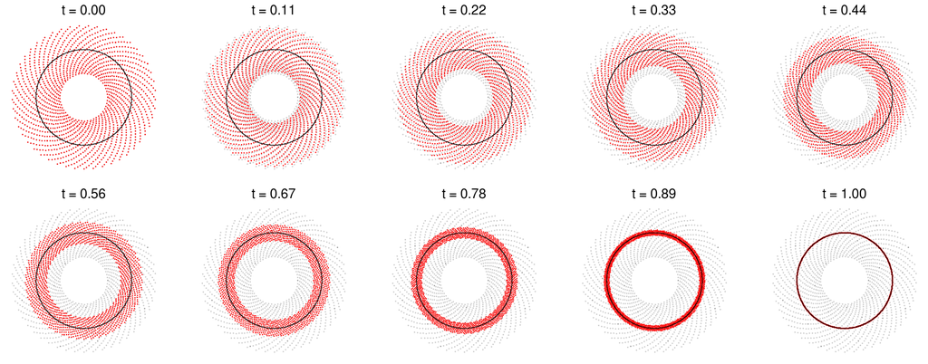

```python
X = sample_X(0.5, 1.5) # generate sampled annulus
S1 = sample_X(1, 1) # generate sampled unit circle
tv = np.linspace(0,1,10) # generate t for h(X,t)

# Plot per t
plt.figure(figsize=(20,8))
for cnt,t in enumerate(tv):
    hX = h_X(X,t)
    plt.subplot(2,5,cnt+1)
    plt.scatter(X[:,0], X[:,1], c='k', marker='.', s=10, alpha=0.2)
    plt.scatter(hX[:,0], hX[:,1], c='r', marker='.', s=10)
    plt.scatter(S1[:,0], S1[:,1], c='k', marker='.', s=2)
    plt.axis('off')
    plt.gca().set_aspect('equal')
    plt.title('t = %.2f' %(t))

plt.tight_layout()
plt.show();
```

## Question 2 - simplicial complexes

### 2.1. Rips vs Cech

#### **Observations**

The sides of the unit circle equilateral triangle would be equally $d = 2 \sin(\pi/3) \approx 1.732$.

Basically, $d_{ij} = d(x_i,x_j) = d \ \forall x_i, x_j \in X, i,j \in \{1,2,3\}, i \neq j$

**Observation**: for $i \neq j \neq k \neq i$

**(1a)** If $\mathcal{B}(x_i;r) \cap \mathcal{B}(x_j;r) = \emptyset$ then $\mathcal{B}(x_k;r) \cap \mathcal{B}(x_{i,j} ;r) = \emptyset$

**(1b)** If $\mathcal{B}(x_i;r) \cap \mathcal{B}(x_j;r) \neq \emptyset$ then $\mathcal{B}(x_k;r) \cap \mathcal{B}(x_{i,j} ;r) \neq \emptyset$ (only pairwise, not three-way)

**(2)** If $r \ge 1$ then $\bigcap \mathcal{B}(x_{i,j,k} ;r) \neq \emptyset$ (three-way)

**Proof**:

**(1a)** Assume intersections of the balls with the line connecting $x_i$ and $x_j$ are $y_i$ and $y_j$ respectively.

Since the 2 balls don't intersect with each other, $d = d_{ij} > |x_i - y_i| + |x_j - y_j| = r+r = 2r$, basically $ r < d/2 \qquad (\star_1)$.

Assume that $\exists y \in \mathcal{B}(x_k;r) \cap \mathcal{B}(x_i;r)$. Due to the triangle inequality: $r + r = |x_i - y| + |x_k - y| \ge |x_i - x_k| = d_{ik} \Rightarrow 2r \ge d \qquad (\star_2)$ (contradiction with $(\star_1)$).

Hence $\mathcal{B}(x_k;r) \cap \mathcal{B}(x_i ;r) = \emptyset$ and similarly for $\mathcal{B}(x_k;r) \cap \mathcal{B}(x_j;r) = \emptyset $

**(1b)** Since the 2 balls intersect, due to the triangle inequality $r \ge d/2$ (like $(\star_2)$)

If $\mathcal{B}(x_k;r) \cap \mathcal{B}(x_i;r) = \emptyset$, similar to $(\star_1)$, we'd have $r < d/2$, contradicting with the above inequality.

Hence $\mathcal{B}(x_k;r) \cap \mathcal{B}(x_i;r) \neq \emptyset$, and similarly $\mathcal{B}(x_k;r) \cap \mathcal{B}(x_j;r) \neq \emptyset$

**(2)** With $A, B, C \in \mathcal{B}(O,1)$ (instead of looking at the vectors $x_{i,j,k}$), then $|BO| = 1, |BC| = d$. Define the altitude $\overline{AH}$.

Because $r \ge 1 > d/2$, the balls would intersect pairwisely with each other but there is no guarantee there is a 3-way intersection.

Assume the balls at $B$ and $C$ intersect at $K$. Due to symmetry this point also lies on the altitude $\overline{AH}$. In other words, $\mathcal{B}(B;r) \cap \mathcal{B}(C;r) \cap \overline{AH} = K$

[figure not shown]

Additionally, because $|KH| = \sqrt{BK^2 - BH^2} = \sqrt{r^2 - d^2/4} \ge \sqrt{1 - d^2/4} = \sqrt{BO^2 - BH^2} = |OH|$

$ \Rightarrow |KH| \ge |OH| \Rightarrow |AK| \le |AO| = 1 \le r \Rightarrow K \in \mathcal{B}(A;r)$

Hence $\displaystyle \bigcap_{P = A,B,C} \mathcal{B}(P;r) \ni K \neq \emptyset$

#### **(a) For what values of r are Rips and Cech identical?**

If neither pairs of balls intersect, or actually just need to check one pair of balls not intersecting, based on observation **(1a)**, meaning $r < d/2$, the two complexes are identical as they both represent three 0-simplices.

If exists a pair of balls intersecting with $d/2 \le r \lt 1$, then based on observation **(1b)**, the Rips complex is a 2-simplex but the Cech complex is a set of three connected 1-simplices.

But if $r \ge 1$, the Cech complex becomes the 2-simplex, similar to the Rips complex

Hence for $r \in [0,d/2) \cup [1,\infty)$ then $R(X;r) \simeq \check{C}(X;r)$

#### **(b) For what values of r are Cech is homotopic to a unit circle?**

Only when $d/2 \le r \lt 1$ is $\check{C}(X;r)$ is a collection of connected 1-simplices (triangle with only sides without face), which is homotopic to a unit circle $S^1$.

#### **(c) For what values of r are Rips is homotopic to a unit circle?**

There is no $r$ that $R(X;r) \simeq S^1$. As explained in (a), Rips complex either becomes a set of disconnected 0-simplices or a 2-simplex. Neither of these cases is homotopic to a unit circle. At best the latter is homotopic to a disk, which is homotopic to a point.

Regardless, we'd need at least 4 points if we want a Rips complex homotopic to a unit circle.

### 2.2 Constructing Rips complexes

#### Define essential functions

```python
# Importing TDA packages for comparison
import dionysus
import gudhi as gd

# For plotting hypergraph (for visualizing cover sets and nerves)
import hypernetx as hnx
from networkx import fruchterman_reingold_layout as layout
```

```python
# Functions for generating data
def sample_circle(n, r, s_r, noise_distrib=None):
    """
    Description: Sample from circle in with noise, center at origin
    Input:
        n: number of points
        r: radius of circle
        s_r: range or variability of the radius. Depends on choice of `noise_distrib`
                - if noise is gaussian, `s_r` would be the standard deviation of the distribution
                - if noise if uniform, the range would be `[r-s_r/2,r+s_r/2]`
        noise_distrib: (optional, default=`None`) specification of noise distribution
                - "normal" or "gaussian" or `None`: normal distribution
                - "uniform": uniform distribution
    Output:
        A 2D matrix of the coordinates of size (`n`) x 2.
        Each row is a point. Each column is a coordinate
    """

    # Generate radius vector
    if noise_distrib is None:
        noise_distrib = 'normal'
    noise_distrib = noise_distrib.lower()
    if 'norm' in noise_distrib or 'gauss' in noise_distrib:
        rv = np.random.normal(loc=r,scale=s_r,size=(n,1))
    elif noise_distrib == 'uniform':
        rv = np.random.uniform(low=r-s_r/2,high=r+s_r/2,size=(n,1))
    else:
        raise ValueError('"%s" is not allowed as a noise distribution type' %(noise_distrib))

    # Generate phase vector, with a tinsy bit of noise
    thetav = np.linspace(0,2*np.pi,n)[:,None]
    thetav = thetav + np.random.uniform(low=-1,high=1,size=(n,1))*np.pi/(4*n)

    return np.hstack((rv * np.cos(thetav),rv * np.sin(thetav)))

def sample_doublecircle(n, r1, r2, d12, s_r, noise_distrib=None):
    """
    Description: Sample from 2 circles in with noise,
        one (`r1`) with center at origin, the other (`r2`) displaced with `d12`
    Input:
        n: number of points, will be divided in a proportional way between `r1` and `r2`
        r1, r2: radii of circles
        d12: vector (or scale) representing the displacement of the 2 circles
        s_r: see description in :func:`sample_circle`
        noise_distrib: (optional, default=`None`) see description in :func:`sample_circle`
    Output:
        A 2D matrix of the coordinates of size (`n`) x 2.
        Each row is a point. Each column is a coordinate
    """

    n1 = round(n * r1/(r1+r2))
    n2 = n - n1
    X1 = sample_circle(n1, r1, s_r, noise_distrib)
    X2 = sample_circle(n2, r2, s_r, noise_distrib) + d12
    return np.vstack((X1,X2))
```

```python
# Functions dealing with simplicial complexes

def flatten_list(L):
    """ Simple flatten a double-nested list, also flatten 2D matrix if needed, return list"""
    Lf = []
    [Lf.extend(li) for li in L]
    return Lf

def naive_rips(X, k, r):
    """
    Description: Naive implementation looking for Rips complexes
    Note: peruse `gudhi.SimplexTree` simplicial complex data structure,
            performed really slow (hence "naive") so just good for playing purposes
    Input:
        X: a matrix of size N x M, where N is the number of points, M is the dimension
        k: max simplex dimension
        r: radius diameter
    Output:
        st: a `gudhi.SimplexTree` containing the simplicial complex
        spx_list: list of only the simplices
    """
    N = X.shape[0]
    vertex_list = np.arange(N)

    # Process 0-simplices
    st = gd.SimplexTree()
    [st.insert([v]) for v in vertex_list]
    if k < 1:
        return st

    # Process 1-simplices
    dX = pw_dist(X, metric='euclidean')
    rv, cv = np.where(dX < r)
    rv, cv = rv[rv < cv], cv[rv < cv] # reduce duplicates

    spx_list = []
    [st.insert([ri, ci]) and spx_list.append([ri, ci]) for ri, ci in zip(rv,cv)]

    # Process higher simplices
    ki = 2
    new_spx_list = []
    while ki <= k:
        # go through the old simplex list
        # look for vertices that connect with all the vertices the inquired simplex
        # then add as a new simplex
        for s in spx_list:
            # filter only vertices that are within the balls of the current simplex `s`
            avail_vert = [np.where(np.logical_or(si == rv, si == cv))[0] for si in s]
            avail_vert = set(flatten_list(avail_vert))
            avail_vert = set(flatten_list([[rv[x], cv[x]] for x in avail_vert]))

            for v in avail_vert:
                if v in s: continue
                new_spx = list(s) + [v]
                # only add the new simplex `new_spx`
                # if all edges from `v` to `s` vertices exist
                add_spx = np.all([st.find([si,v]) for si in s])
                if add_spx:
                    st.insert(new_spx)
                    new_spx_list.append(new_spx)
        spx_list, new_spx_list = new_spx_list, []
        ki += 1

    spx_list = list([x[0] for x in st.get_simplices()])
    return st, spx_list

def compare_ripsgen(X,k,r,sort=False):
    """
    Description: Compare my naive Rips implementation with other TDA packacges
    Input:
        X: a matrix of size N x M, where N is the number of points, M is the dimension
        k: max simplex dimension
        r: radius diameter
        sort: (optional boolean, default=False) whether to sort simplices in string representation
                useful for small list but might take really long for longer
    Output:
        naive_rips_list: list of only the simplices from naive implementation, see :func:`naive_rips`
        str_naiverips: a string representation of `naive_rips_list`
        gd_rips_list: list of only the simplices from `gudhi.SimplexTree`
        str_gdrips: a string representation of `gd_rips_list`
    """
    t0 = time.time()
    dionysus_rips = dionysus.fill_rips(X, k, r)
    print('Using "DIONYSUS" took %.5f seconds' %(time.time() - t0))

    t0 = time.time()
    gd_rips_tree = gd.RipsComplex(X, max_edge_length = r).create_simplex_tree(max_dimension = k)
    gd_rips_list = list(gd_rips_tree.get_filtration())
    gd_rips_list = [x[0] for x in gd_rips_list]
    print('Using "GUDHI" took %.5f seconds' %(time.time() - t0))

    t0 = time.time()
    naive_rips_tree, naive_rips_list = naive_rips(X, k, r)
    print('Using my naive implementation took %.5f seconds' %(time.time() - t0))

    if sort:
        str_naiverips = list(["".join(str(x)) for x in np.sort(np.array(naive_rips_list, dtype=list))])
        str_gdrips = list(["".join(str(x)) for x in np.sort(np.array(gd_rips_list, dtype=list))])
    else:
        str_naiverips = set(list(["".join(str(x)) for x in naive_rips_list]))
        str_gdrips = set(list(["".join(str(x)) for x in gd_rips_list]))

    print('Length of naive rips list = %d' %(len(str_naiverips)))
    print('Length of gudhi rips list = %d' %(len(str_gdrips)))
    print('Are they the same? %s ' %(['NO','YES'][str_naiverips == str_gdrips]))
    return naive_rips_list, str_naiverips, gd_rips_list, str_gdrips

def reduce_faces(spx_list,stop_k=2):
    """
    Description: Reduce faces of higher simplex
    Input:
        spx_list: list of only the simplices
        stop_k: (optional, default=2) order of simplex to stop reducing
                example: `stop_k`=2 would rid til "redundant" triangles
                but not the edges or vertices
    Output:

    """
    len_spx = np.array([len(x) for x in spx_list])
    res_spx = deepcopy(spx_list)
    L_max = max(len_spx)
    for L in np.arange(L_max,stop_k+1,-1):
        spx_L = [spx_list[x] for x in np.where(len_spx == L)[0]]
        for spx in spx_L:
            spx = np.array(spx)
            for s in spx:
                sub_s = list(np.sort(spx[spx != s]))
                if sub_s in res_spx: res_spx.remove(sub_s)
    len_spx = np.array([len(x) for x in res_spx])
    res_spx = {L-1:[res_spx[x] for x in np.where(len_spx == L)[0]] for L in len_spx}
    return res_spx
```

```python
# Functions for plotting

def plot_with_rips(X,spx_dict,spx_colors):
    """
    Description: Plot data points with simplices
    Note: use reduced version of simplex list to avoid crowded figure
    Input:
        X: a coordinate matrix of size N x M, where N is the number of points, M is the dimension
        spx_dict: dictionary of simplices, each element is a simplex list
        spx_colors: dictionary of colors for each simplex order
    """
    plt.scatter(X[:,0],X[:,1],s=2,color=spx_colors[0])

    edges = np.array(spx_dict[1])
    plt.plot([X[edges[:,0],0], X[edges[:,1],0]], [X[edges[:,0],1], X[edges[:,1],1]],
            color=spx_colors[1],lw=0.7,alpha=0.2)

    patches = []
    colors = []

    all_orders = np.array(list(spx_dict.keys()))
    high_orders = all_orders[all_orders > 1]

    for k in high_orders:
        color_kspx = spx_colors[k]
        for spx in spx_dict[k]:
            pts = X[spx,:]
            hull_vert = list(ConvexHull(pts).vertices)
            pts = pts[hull_vert,:]

            patches.append(Polygon(pts,closed=True))
            colors.append(color_kspx)

    collection = PatchCollection(patches)
    plt.gca().add_collection(collection)

    collection.set_color(colors)
    collection.set_alpha(0.2)

    plt.axis('off')
    plt.gca().set_aspect('equal')


def demo_simplex_colors(spx_colors,r=0.7):
    """
    Description: Demo plot simplex and their colors
    Input:
        spx_colors: dictionary of colors for each simplex order
        r: (optional, default=0.7) radius of regular polygon to represent >= 2-simplex
    """

    patches = []
    colors = []
    for k, c in spx_colors.items():
        if k == 0:
            plt.scatter(k,0,s=50,color=c)
        if k == 1:
            plt.plot(k+np.array([-1,1])*r/2+r/4,[0,0],color=c,lw=2,marker='.',markersize=10)
        else:
            patches.append(RegularPolygon((k*2-1,0),k+1,r))
            colors.append(c)

    collection = PatchCollection(patches)
    plt.gca().add_collection(collection)

    collection.set_color(colors)
    collection.set_alpha(0.8)

    plt.xlim([-1,k*2])
    plt.ylim([-r*2,r*2])
    plt.axis('off')
    plt.gca().set_aspect('equal')
```

```python
# Naive nerve finding implementation
def naive_nerve(cover_list, k):
    """
    Description: Naive implementation to find never of set of covers
    Note: peruse `gudhi.SimplexTree` simplicial complex data structure,
            performed really slow (hence "naive") so just good for playing purposes
    Todo: refine a bit on assigning `avail_vert` (though probably might not gain much)
    Input:
        cover_list: a dictionary of sets
        k: max simplex dimension
    Output:
        nerve: nerve of the sets
        reduced_nerve: list reduced nerve flattened
        reduced_nerve_with_order: dictionary of reduced nerve,
                based on order of simplex
        st: a `gudhi.SimplexTree` containing the simplicial complex
                note: the values stored in `st` would be indices only
        set_names: set of the keys of `cover_list`, useful for reference of `st`
    """
    set_names = np.array(list(cover_list.keys()))
    set_list = list(cover_list.values())

    N = len(cover_list)
    vertex_list = np.arange(N)

    vertex_pairs = [(vertex_list[i],vertex_list[j]) for i in range(N-1) for j in range(i+1,N)]
    inter_list = {(i,j): set_list[i].intersection(set_list[j]) for i in range(N-1) for j in range(i+1,N)}

    st = gd.SimplexTree()

    # Processing 0-simplices
    [st.insert([v]) for v in vertex_list]
    if k < 1:
        return st

    # Processing 1-simplices
    spx_list = {k:v for k,v in inter_list.items() if len(v) > 0}
    [st.insert(p) for p in spx_list]

    # Processing higher-order simplices
    ki = 0
    new_spx_list = {}
    while ki < k:
        avail_vert = vertex_list # to lazy to refine
        for s,el in spx_list.items():
            s = set(s)
            for v in avail_vert:
                if v in s: continue
                new_spx = tuple({*s,v})
                s_v_inter = set_list[v].intersection(el)
                add_spx = len(s_v_inter) > 0
                if add_spx:
                    st.insert(new_spx)
                    new_spx_list[new_spx] = s_v_inter

        # for debug: print({tuple(set_names[list(k)]):v for k,v in new_spx_list.items()})
        spx_list, new_spx_list = new_spx_list, {}
        ki += 1

    spx_list = list([x[0] for x in st.get_skeleton(k)])
    nerve = [set(set_names[x]) for x in spx_list]
    reduced_spx = reduce_faces(spx_list,stop_k=0)
    reduced_nerve_with_order = {k:[list(set(set_names[x])) for x in spx] for k,spx in reduced_spx.items()}
    reduced_nerve = flatten_list(list(reduced_nerve_with_order.values()))

    return nerve, reduced_nerve, reduced_nerve_with_order, st, set_names
```

#### Demo with a small example

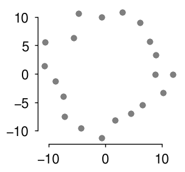

```python
X = sample_circle(20,10,4,'uniform')
k = 3
r = 6

plt.figure(figsize=(3,3))
plt.scatter(X[:,0],X[:,1],c='k',alpha=0.5)
plt.gca().set_aspect('equal')

sns.despine(trim=True)
plt.show();
```

```python
_, str_naiverips, _, str_gdrips = compare_ripsgen(X,k,r,sort=True)
```

```
Using "DIONYSUS" took 0.00009 seconds
Using "GUDHI" took 0.00015 seconds
Using my naive implementation took 0.00340 seconds
Length of naive rips list = 50
Length of gudhi rips list = 50
Are they the same? YES
```

```python
# Later I will just compare between the strings instead of displaying tables
df = pd.DataFrame({'naive': list(str_naiverips), 'gudhi': list(str_gdrips)})

print('Table of simplices')
display(df)
```

```
Table of simplices
```

|  | naive | gudhi |
| --- | --- | --- |
| 0 | [0] | [0] |
| 1 | [0, 1] | [0, 1] |
| 2 | [0, 1, 19] | [0, 1, 19] |
| 3 | [0, 18] | [0, 18] |
| 4 | [0, 18, 19] | [0, 18, 19] |
| 5 | [0, 19] | [0, 19] |
| 6 | [1] | [1] |
| 7 | [1, 2] | [1, 2] |
| 8 | [1, 2, 19] | [1, 2, 19] |
| 9 | [1, 19] | [1, 19] |
| 10 | [2] | [2] |
| 11 | [2, 3] | [2, 3] |
| 12 | [2, 19] | [2, 19] |
| 13 | [3] | [3] |
| 14 | [3, 4] | [3, 4] |
| 15 | [4] | [4] |
| 16 | [4, 5] | [4, 5] |
| 17 | [5] | [5] |
| 18 | [5, 6] | [5, 6] |
| 19 | [6] | [6] |
| 20 | [6, 7] | [6, 7] |
| 21 | [7] | [7] |
| 22 | [7, 8] | [7, 8] |
| 23 | [8] | [8] |
| 24 | [8, 9] | [8, 9] |
| 25 | [9] | [9] |
| 26 | [9, 10] | [9, 10] |
| 27 | [10] | [10] |
| 28 | [10, 11] | [10, 11] |
| 29 | [11] | [11] |
| 30 | [11, 12] | [11, 12] |
| 31 | [12] | [12] |
| 32 | [12, 13] | [12, 13] |
| 33 | [13] | [13] |
| 34 | [13, 14] | [13, 14] |
| 35 | [14] | [14] |
| 36 | [14, 15] | [14, 15] |
| 37 | [15] | [15] |
| 38 | [15, 16] | [15, 16] |
| 39 | [15, 16, 17] | [15, 16, 17] |
| 40 | [15, 17] | [15, 17] |
| 41 | [16] | [16] |
| 42 | [16, 17] | [16, 17] |
| 43 | [17] | [17] |
| 44 | [17, 18] | [17, 18] |
| 45 | [17, 18, 19] | [17, 18, 19] |
| 46 | [17, 19] | [17, 19] |
| 47 | [18] | [18] |
| 48 | [18, 19] | [18, 19] |
| 49 | [19] | [19] |

#### Demo with more samples

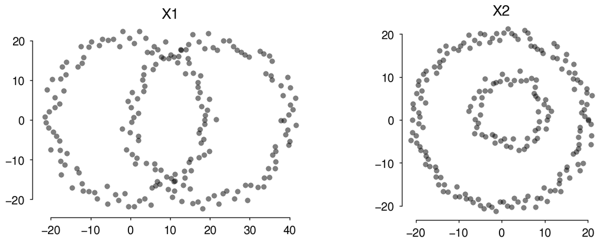

```python
X1 = sample_doublecircle(200,20,20,np.array([20,0]),5,'uniform')
X2 = sample_doublecircle(200,20,8,np.array([2,2]),3.5,'uniform')

plt.figure(figsize=(15,5))

plt.subplot(121)
plt.scatter(X1[:,0],X1[:,1],c='k',alpha=0.5)
plt.gca().set_aspect('equal')
plt.title('X1')

plt.subplot(122)
plt.scatter(X2[:,0],X2[:,1],c='k',alpha=0.5)
plt.gca().set_aspect('equal')
plt.title('X2')

sns.despine(trim=True)
plt.show();
```

```python
k1, k2 = 4, 3
r1, r2 = 5, 3

print('Rips with X1,k1=%d,r1=%d' %(k1,r1))
print('-'*50)
naive_rips_list_1, _, _, _ = compare_ripsgen(X1,k1,r1)

print('_'*50)
print('\nRips with X2,k2=%d,r2=%d' %(k2,r2))
print('-'*50)
naive_rips_list_2, _, _, _ = compare_ripsgen(X2,k2,r2)
```

```
Rips with X1,k1=4,r1=5
--------------------------------------------------
Using "DIONYSUS" took 0.00472 seconds
Using "GUDHI" took 0.00369 seconds
Using my naive implementation took 3.33752 seconds
Length of naive rips list = 4104
Length of gudhi rips list = 4104
Are they the same? YES
__________________________________________________

Rips with X2,k2=3,r2=3
--------------------------------------------------
Using "DIONYSUS" took 0.00215 seconds
Using "GUDHI" took 0.00184 seconds
Using my naive implementation took 0.19152 seconds
Length of naive rips list = 1219
Length of gudhi rips list = 1219
Are they the same? YES
```

#### Demo-ing reducing faces

```python
example_spxlist = [
    [1],[2],[3], # none will be reduced if stop_k > 0, otherwise [2] and [3] will be
    [4,5], # won't be reduced
    [2,3],[3,6],[6,7], # none will be reduced if stop_k > 1, otherwise will be removed due to [2,3,6,7]
    [2,3,4], # won't be reduced
    [2,3,6],[2,3,7],[2,6,7],[3,6,7],[2,3,6,7], # will be reduced to the 3-simplex: [2,3,6,7]
    [10,11], # will not be reduced if stop_k > 1, otherwise will be reduced due to the following simplices
    [10,11,12],[11,12,14],[10,11,12,13],[10,11,12,14],[10,11,13,14],[10,12,13,14],[11,12,13,14], # will be reduced to the 4-simplex below
    [10,11,12,13,14], # the 4-simplex containing the faces above
    [11,12,15],[11,12,14,15] # will be reduced to 3-simplex [11, 12, 14, 15]
]

for stop_k in [2,1,0]:
    print('Reduced for "stop_k" = %d:' %(stop_k))
    reduce_faces(example_spxlist, stop_k=stop_k)
```

```
Reduced for "stop_k" = 2:
```

```
{0: [[1], [2], [3]],
 1: [[4, 5], [2, 3], [3, 6], [6, 7], [10, 11]],
 2: [[2, 3, 4]],
 3: [[2, 3, 6, 7], [11, 12, 14, 15]],
 4: [[10, 11, 12, 13, 14]]}
```

```
Reduced for "stop_k" = 1:
```

```
{0: [[1], [2], [3]],
 1: [[4, 5]],
 2: [[2, 3, 4]],
 3: [[2, 3, 6, 7], [11, 12, 14, 15]],
 4: [[10, 11, 12, 13, 14]]}
```

```
Reduced for "stop_k" = 0:
```

```
{0: [[1]],
 1: [[4, 5]],
 2: [[2, 3, 4]],
 3: [[2, 3, 6, 7], [11, 12, 14, 15]],
 4: [[10, 11, 12, 13, 14]]}
```

#### Plotting

```python
reduced_rips_1 = reduce_faces(naive_rips_list_1)
reduced_rips_2 = reduce_faces(naive_rips_list_2)
```

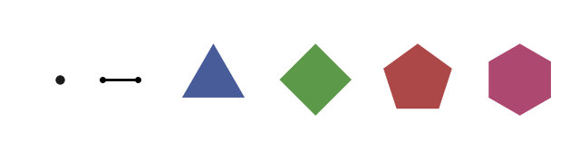

```python
simplex_colors = {
    0: [0.1,0.1,0.1], # vertices
    1: [0,0,0],       # edges
    2: [0.1,0.2,0.5], # 2-simplex triangles
    3: [0.2,0.5,0.1], # and so on and so forth ...
    4: [0.6,0.1,0.1],
    5: [0.6,0.1,0.3]
}

demo_simplex_colors(simplex_colors)
plt.show();
```

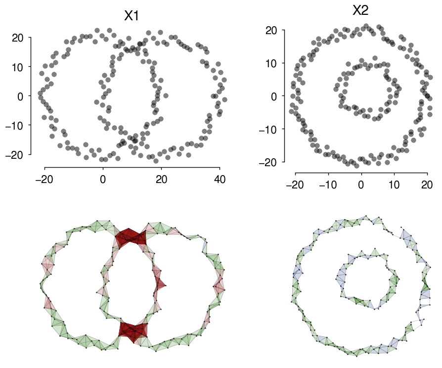

```python
plt.figure(figsize=(10,8))

plt.subplot(2,2,1)
plt.scatter(X1[:,0],X1[:,1],c='k',alpha=0.5)
plt.gca().set_aspect('equal')
plt.title('X1')

plt.subplot(2,2,3)
plot_with_rips(X1,reduced_rips_1,simplex_colors)

plt.subplot(2,2,2)
plt.scatter(X2[:,0],X2[:,1],c='k',alpha=0.5)
plt.gca().set_aspect('equal')
plt.title('X2')

plt.subplot(2,2,4)
plot_with_rips(X2,reduced_rips_2,simplex_colors)

plt.tight_layout()
sns.despine(trim=True)
plt.show();
```

### 2.3 Nerve

```python
cover_list = {
    'A':{1,2,3,4,5},
    'B':{4,5,6},
    'C':{6,7,8,9,10,11},
    'D':{3,5,6,7},
    'E':{12,13,14,15},
    'F':{10,11,12},
    'G':{1,12,15},
    'H':{12,16,17}
}
```

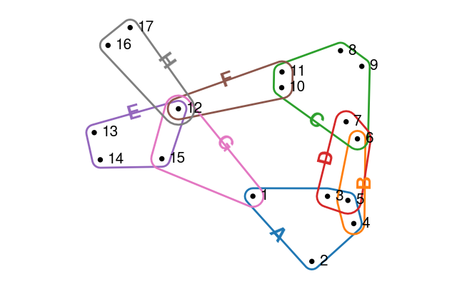

```python
# Visualization
H = hnx.Hypergraph(cover_list)

graph_args = dict(
    with_edge_labels=True,
    edges_kwargs={'linewidths': 2},
    node_labels_kwargs={'fontsize': 15},
    edge_labels_kwargs={'fontsize': 20,'fontweight':'bold'},
    node_radius=0.7,
    label_alpha=0,
    layout_kwargs={'seed': 10}
)

plt.figure(figsize=(8,5))
hnx.drawing.draw(H, **graph_args)
plt.show();
```

```python
nerve, reduced_nerve, reduced_nerve_with_order, _, _ = naive_nerve(cover_list, k=3)
```

```python
nerve # all simplices
```

```
[{'A', 'B', 'D'},
 {'A', 'B'},
 {'A', 'D'},
 {'A', 'G'},
 {'A'},
 {'B', 'C', 'D'},
 {'B', 'C'},
 {'B', 'D'},
 {'B'},
 {'C', 'D'},
 {'C', 'F'},
 {'C'},
 {'D'},
 {'E', 'F', 'G', 'H'},
 {'E', 'F', 'G'},
 {'E', 'F', 'H'},
 {'E', 'F'},
 {'E', 'G', 'H'},
 {'E', 'G'},
 {'E', 'H'},
 {'E'},
 {'F', 'G', 'H'},
 {'F', 'G'},
 {'F', 'H'},
 {'F'},
 {'G', 'H'},
 {'G'},
 {'H'}]
```

```python
reduced_nerve_with_order # reduced, sorted in order
```

```
{2: [['B', 'D', 'A'], ['C', 'D', 'B']],
 1: [['G', 'A'], ['C', 'F']],
 3: [['F', 'H', 'E', 'G']]}
```

```python
reduced_nerve # flattened for visualization
```

```
[['B', 'D', 'A'],
 ['C', 'D', 'B'],
 ['G', 'A'],
 ['C', 'F'],
 ['F', 'H', 'E', 'G']]
```

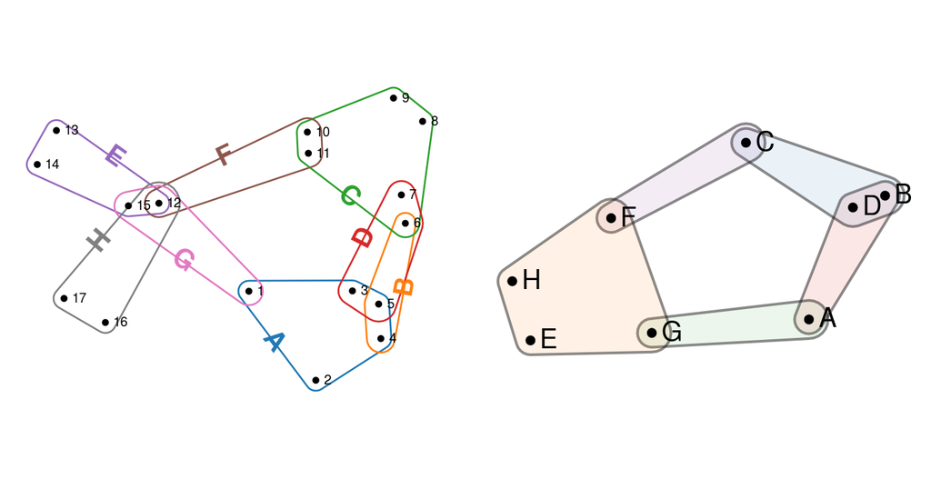

```python
# Visualization
cmap = plt.get_cmap('Set1')
colors = cmap(np.arange(len(cover_list)))
colors[:,-1] = 0.1
plt.figure(figsize=(15,8))

H = hnx.Hypergraph(cover_list)

ax1 = plt.subplot(121)
hnx.drawing.draw(H, ax=ax1,
                 with_edge_labels=True,
                 edges_kwargs={'linewidths': 2},
                 node_labels_kwargs={'fontsize': 15},
                 edge_labels_kwargs={'fontsize': 30,'fontweight':'bold'},
                 node_radius=0.7,
                 label_alpha=0,
                 layout_kwargs={'seed': 30})

H = hnx.Hypergraph(reduced_nerve)

ax2 = plt.subplot(122)
hnx.drawing.draw(H, ax=ax2,
                 with_edge_labels=False,
                 edges_kwargs={'linewidths': 3,'edgecolors':[0.1,0.1,0.1,0.5],'facecolors':colors},
                 nodes_kwargs={'color':'k'},
                 node_labels_kwargs={'fontsize': 30},
                 node_radius=1,
                 label_alpha=0,
                 layout_kwargs={'seed': 1201920})
plt.tight_layout()
plt.show();
```

## Question 3

```python
# Run first 2 cells in initialization first
import kmapper as km
from kmapper.plotlyviz import plotlyviz

from sklearn.preprocessing import StandardScaler
from sklearn.decomposition import PCA
from sklearn import cluster

# somehow orca exec was not recognized, weird, so workaround
import sys, plotly
plotly.io.orca.config.executable = sys.exec_prefix + '/bin/orca'
```

```python
df = pd.read_csv('data/chemdiab.csv')
display(df)

df = df.to_numpy()
X, labels = df[:,:5], df[:,-1]
classes = np.unique(labels)
```

|  | rw | fpg | ga | ina | sspg | cc |
| --- | --- | --- | --- | --- | --- | --- |
| 0 | 0.81 | 80 | 356 | 124 | 55 | Normal |
| 1 | 0.95 | 97 | 289 | 117 | 76 | Normal |
| 2 | 0.94 | 105 | 319 | 143 | 105 | Normal |
| 3 | 1.04 | 90 | 356 | 199 | 108 | Normal |
| 4 | 1.00 | 90 | 323 | 240 | 143 | Normal |
| ... | ... | ... | ... | ... | ... | ... |
| 140 | 1.05 | 353 | 1428 | 41 | 480 | Overt_Diabetic |
| 141 | 0.91 | 180 | 923 | 77 | 150 | Overt_Diabetic |
| 142 | 0.90 | 213 | 1025 | 29 | 209 | Overt_Diabetic |
| 143 | 1.11 | 328 | 1246 | 124 | 442 | Overt_Diabetic |
| 144 | 0.74 | 346 | 1568 | 15 | 253 | Overt_Diabetic |

145 rows × 6 columns

```python
mapper = km.KeplerMapper()
clusterer = cluster.DBSCAN(eps=200,min_samples=2)
cover = km.Cover(n_cubes=20,perc_overlap=0.6)
projections = PCA(n_components=2,whiten=True)

proj_X = mapper.fit_transform(X, projection=projections)
graph = mapper.map(proj_X, X, cover=cover, clusterer=clusterer)

mapper.visualize(graph, path_html="figures/chemdiab.html",
                 title="chem diabetes mapper");
```

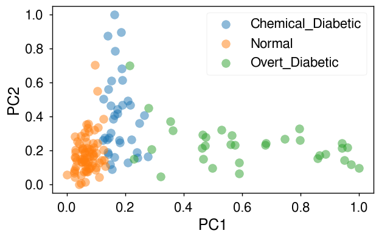

```python
plt.figure(figsize=(15,4))
plt.subplot(121)
[plt.scatter(proj_X[labels==lbl,0], proj_X[labels==lbl,1], s=100, label=lbl,alpha=0.5) for lbl in classes]
plt.legend()
plt.xlabel('PC1')
plt.ylabel('PC2')
plt.show();
```

```python
plotlyviz(graph, title="chem diabetes mapper",
          dashboard=False, graph_layout='fr',
          edge_linewidth=0.5, factor_size=3,
          node_linecolor='rgba(0,0,0,0)',
          bgcolor='rgba(255, 255, 255, 1)',
          width=800, height=700,
          filename="figures/chemdiab.png")
```

In case the figure is not shown:

[figure not shown]